# Cannabis in California and New York

**Erwin Feuzeu**

Introduction to Computational Thinking.

Final Project

# Introduction

California and New York are two large states in the United States of America[1]. Since they have both legalized cannabis, also known as marijuana, in some form and are also geographically different I am interested in comparing the information and data of both states[2].

# Abstraction

Abstraction is the process of representing real world entities by quantitative information, or properties, from the viewpoint of a stakeholder interested in answering questions about the real world entity. The **abstraction of drugs** used in this project is a list of drug use reports. Each report contains the following quantitative information:

California and New York are two of the five most populated states in the United States of America[1]. This makes comparing the two states interesting as they both possess large numbers of people while also being geographically seperated from each other. The analysis of the drugs data stream will answer the following questions:

1. How do the level of cannabis use for 12-17 and 17-25 year olds compare for California and New York?
2. What is the trend of cannabis use for 17-25 year olds in California and New York?
3. What is the relationship between perceptions of risk and cannabis use in the past month for 17-25 year olds in California and New York?

The first question gives insight on how heavily the two different age groups use marijuana as well as how those age groups differ is usage by state. The second question provides answers on how popular marijuana use as a whole has become over time in both states. The third question allows us to see if having a higher perception of risk in marijuana will result in more or less usage of the drug in either state. Does the risk entice most people of this age group to participate or scare them?

These questions carry great importance for many reasons. First, cannabis is a dangerous drug that should not be used by anyone over the age of 21 let alone 12-17 year olds. Any data on drug use by that age group chould be utilized in order to help lower the spread of drugs. Secondly, 17-25 year olds will encompass the age that most college students will be, and as a result analyzing the trends of cannabis use for this age group could forecast how marijuana will be viewed in the future. Third, analyzing the relationship between perceptions of risk and cannabis use allows us to see not only the plausible thought proccess of 17-25 year olds and also detect a possible error in how cannabis is perceived by this age group.

[1]"The 50 US States Ranked By Population". See:https://www.worldatlas.com/articles/us-states-by-population.html

[2]"WONDERING WHAT THE LAW IS IN YOUR STATE?". See:https://disa.com/map-of-marijuana-legality-by-state

# Limitations

The data obtained from this study will be limited buy the time period as data pertaining to the topic hand is only contains information from 2002 to 2014. This results in us having a time period that is smaller then preferred as it barely spans over a decade. Also the most recent data used in the study is from 2014, and since then flucuations in cannabis use have occurred. Another limitiation on the data set is the restriction placed by the age groupings. Instead of being able to retrieve information on any single exact age we desire we have to instead settle for using data from the groups offered by the data set. This stops us from getting data on certain ages that would otherwise prove to yield interesting analysis due to the responsibilities attributed with them. For example, the age 16 has the right to drive, the age 18 has the right of becoming an adult, and the age 21 has the right to drink, and smoke cannabis(in legal states only). Also this would mean that a 12 year old boy would be held in the same light as a 17 year old boy. This is not a fair comparison and would lead to misconstrued data as cannabis affects young children differently.

# Data Set

The data about cannabis use for a one month period can be obtained as follows:

```python
import drugs
import matplotlib.pyplot as plt
#get all drug reports
drug_list = drugs.get_reports()
```

# Structure

The data map in the diagram below shows the structure of the drug data set. The entire data set is a list of dictionaries. Each element of the list describes a drug report. This version of the data map is a filtered version only describing properties used in this study. Other properties have a "...." notation to represent the continued dataset. This study only utilizes the rates of marijuana and the year and state. As a result, the properties of interest in this project are:

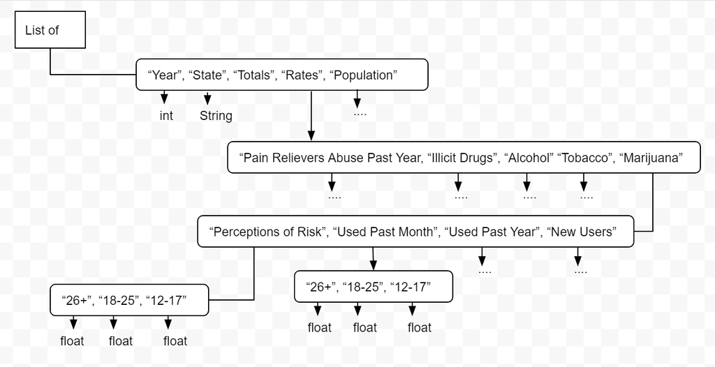

# Question 1

**How do the level of cannabis use for 12-17 and 17-25 year olds compare for California and New York?**

Answering this question involves comparing the scatter plots of cannabis use in the past month, for both 12-17 year olds and 17-25 year olds.

## Code for question

In the following code iteration is used to examine the drug reports. The name of the state where the drug report is recorded is obtained using the key "State". If the reported drug report is in the state of interest, California or New York, it's age group, 18-25 or 12-17, will be appended into the corresponding list initialized earlier. The age group is obtained using the keys, "Rates", "Marijuana", and "Used Past Month". After the iteration, a scatter plot is created for each list. Titles and labels are added to explain the content of the visualization

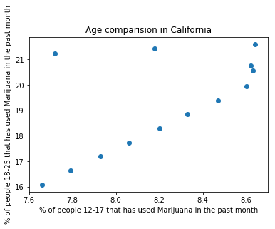

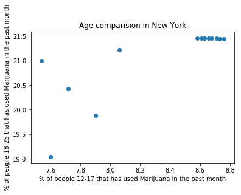

```python
CA_Q1_P1_list = []
CA_Q1_P2_list = []
NY_Q1_P1_list = []
NY_Q1_P2_list = []

for drug in drug_list:
    if drug["State"] == "California":
        CA_Q1_P1_list.append(drug["Rates"]["Marijuana"]["Used Past Month"]["18-25"])
    if drug["State"] == "California":
        CA_Q1_P2_list.append(drug["Rates"]["Marijuana"]["Used Past Month"]["12-17"])
    if drug["State"] == "New York":
        NY_Q1_P1_list.append(drug["Rates"]["Marijuana"]["Used Past Month"]["18-25"])
    if drug["State"] == "New York":
        NY_Q1_P2_list.append(drug["Rates"]["Marijuana"]["Used Past Month"]["12-17"])


plt.scatter(CA_Q1_P2_list, CA_Q1_P1_list)
plt.xlabel("% of people 12-17 that has used Marijuana in the past month")
plt.ylabel("% of people 18-25 that has used Marijuana in the past month")
plt.title("Age comparision in California")
plt.show()
plt.scatter(NY_Q1_P2_list, NY_Q1_P1_list)
plt.xlabel("% of people 12-17 that has used Marijuana in the past month")
plt.ylabel("% of people 18-25 that has used Marijuana in the past month")
plt.title("Age comparision in New York")
plt.show()
```

## Answer to Question 1

The scatter plots above show that while there does appear to be a positive correlation between the age groups in California, New York does appear to have to same case. You can see how that while accounting for a few outliers the scatter plot for California is a positively slope line but for New York no line can by mapped out as the points are scattered except for the cluster in the top right. Also it is apparent that in both states the percentage is greater for the 18-25 age group.

# Question 2

Another comparision of California and New York is whether there is a difference in how marijuana has been trending. This is captured by the following question:

**What is the trend of cannabis use for 17-25 year olds in California and New York?**

Answering this question requires comparing the line graphs of both states for marijuna use in the past month over time.

## Code for question 2

The code in the following cell produces a line graph for each state of 17-25 marijuna use in the past month over time. Because we already created a list of this age group's marijuna use in the past month for bothe list, we just need to create a list for the years of both states. The code used iteration to create these two list, as it checked if the report was present in the two states of interest and if so would append the year to the corresponding state list. The year of the report was accessed with the "Year" key.

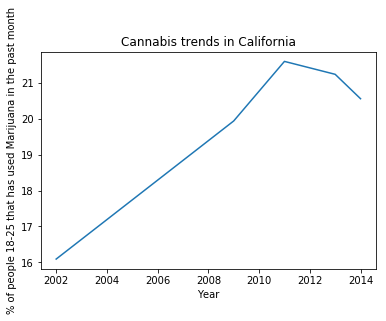

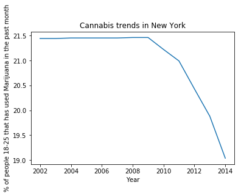

```python
CA_year = []
NY_year = []
for drug in drug_list:
    if drug["State"] == "California":
        CA_year.append(drug["Year"])
    if drug["State"] == "New York":
        NY_year.append(drug["Year"])
plt.plot(CA_year, CA_Q1_P1_list)
plt.xlabel("Year")
plt.ylabel("% of people 18-25 that has used Marijuana in the past month")
plt.title("Cannabis trends in California")
plt.show()

plt.plot(NY_year, NY_Q1_P1_list)
plt.xlabel("Year")
plt.ylabel("% of people 18-25 that has used Marijuana in the past month")
plt.title("Cannabis trends in New York")
plt.show()
```

## Answer to question 2

The line plots above show that California and New York have different trends in cannabis use over the indicated time span. Cannabis use in California has been postitively trending over time for this age group as indicated by the positive slope of its line plot. New York on the other hand has been trending downwards in terms of cannabis use over time as shown by its line plot's steep decline around the year 2009. The difference in trend between the two states could be caused by the fact the cannabis is only decriminilized in New York[1].

# Question 3

Another way of comparing cannabis activity in California and New York is by asking:

**What is the relationship between perceptions of risk and cannabis use in the past month for 17-25 year olds in California and New York?**

Answering this question requires comparing the scatter plots both age groups in both states.

## Code for question 3

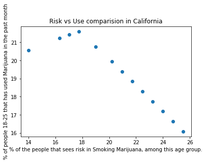

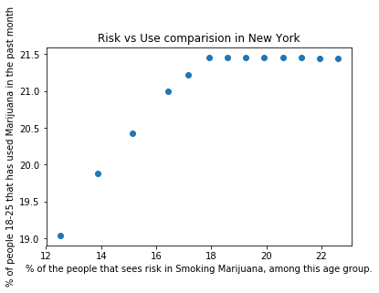

```python
CA_risk = []
NY_risk = []

for drug in drug_list:
    if drug["State"] == "California":
        CA_risk.append(drug["Rates"]["Marijuana"]["Perceptions of Risk"]["18-25"])
    if drug["State"] == "New York":
        NY_risk.append(drug["Rates"]["Marijuana"]["Perceptions of Risk"]["18-25"])

plt.scatter(CA_risk, CA_Q1_P1_list)
plt.xlabel("% of the people that sees risk in Smoking Marijuana, among this age group.")
plt.ylabel("% of people 18-25 that has used Marijuana in the past month")
plt.title("Risk vs Use comparision in California")
plt.show()
plt.scatter(NY_risk, NY_Q1_P1_list)
plt.xlabel("% of the people that sees risk in Smoking Marijuana, among this age group.")
plt.ylabel("% of people 18-25 that has used Marijuana in the past month")
plt.title("Risk vs Use comparision in New York")
plt.show()
```

## Answer to question 3

The scatter plots below show that once again California and New York appear to have differing trends. For California there appears to be a negative correlation meaning that the greater the risk found in smoking cannabis the less likely this age group is to participate. This thought process would appear to be the "common sense" one as most people would prefer to engage in activity with lower risk to their health so it's fair to say a trend like this was expected. However, in New York, the trend is opposite as the correlation is postitive. That means that the greater the risk is the more likely a person of this age group in New York will be to engage in smoking cannabis.

## Social Impacts

Multiple stakeholders would have interest in the results of this study:

- **Cannabis dealers** will be interested in knowing what age group would appeal most to them in order to maximize their profits as well as which state would increase profit as well.
- **Cannabis users** will be interested in whch state or age group would be more likely to have other users among them, as well as where they place on the total spectrum.
- **Policy makers** will be interested in this information in order to know how different ages groups have responded to cannabis in the past few years in order to adjust laws.
- **Parents of cannabis users** will be interested in knowing what ages to watch for cannabis use and how they may differ if resideing in either state.

There are also many conflicts among the stakeholders:

- Cannabis dealers might not want policy makers to reform drug laws.
- Cannabis users will not want parents receiving additional information about cannabis trends.

## Honor Code Statement

I have neither given nor received unathorized assistance on this project.